# Gene Functional Enrichment Analysis

This report covers functional enrichment of the genes that change between the **biofilm** and **planktonic** lifestyles in *Staphylococcus aureus* ([Tomlinson *et al.*, 2021](https://doi.org/10.1099/mgen.0.000598)). The contrast analysed here is the *lifestyle (additive)* model from the differential expression step: the overall biofilm-versus-planktonic difference, controlling for time point.

We apply two complementary approaches:

- **ORA** (Over-Representation Analysis) using [`mulea`](https://github.com/ELTEbioinformatics/mulea) - tests whether the significant DE genes are enriched in a gene set more than expected by chance, with empirical FDR correction.
- **GSEA** (Gene Set Enrichment Analysis) using [`fgsea`](https://bioconductor.org/packages/fgsea/) - uses the full ranked gene list to detect coordinated shifts, including changes below the significance threshold.

Both use the gene sets built by `02b_prepare_genesets_saureus.Rmd`: **KEGG pathways**, **GO Biological Process**, and **GO Molecular Function**, all keyed on the pipeline’s locus tags.

### **Why two packages?**

`mulea` provides empirical FDR correction for ORA but its GSEA function does not compute NES (Normalised Enrichment Scores). `fgsea` is the standard for preranked GSEA with proper NES and well-calibrated p-values. Using the best tool for each task gives the most reliable results.

### **Why these gene sets?**

There is no pre-built MSigDB collection for *S. aureus*, and g:Profiler does not support the strain-level references used here. We therefore build gene sets directly from KEGG and from the reference genome’s GO annotation. KEGG gives curated pathways; GO:BP gives biological processes; GO:MF gives molecular activities and broadens coverage, which matters because only a minority of *S. aureus* genes carry a curated pathway assignment.

### Strain parameter

This report is parameterised by `strain`. The two strains use different reference genomes, so they load different DE tables and different cached gene sets. Change the strain below and run again from the top to see the other one, or produce all six reports for both strains at once with `Rscript 01_scripts/render_all_strains.R` from the repository root.

```r
strain <- "usa100"          # "usa100" or "usa500" (interactive default)
if (exists("params", inherits = FALSE) && is.list(params) && !is.null(params$strain)) strain <- params$strain
stopifnot(strain %in% c("usa100", "usa500"))
cat("Enrichment for strain:", strain, "\n")
```

```
## Enrichment for strain: usa500
```

### Load Libraries

```r
library(tidyverse)
library(mulea)
library(fgsea)
library(knitr)
library(kableExtra)
library(DT)
library(ggpubr)   # theme_pubr
```

## Strain configuration and inputs

Everything strain-specific is set here: the DE table for the lifestyle contrast, the cached gene sets, and the output directory. The rest of the script is strain-agnostic.

```r
git_root <- system("git rev-parse --show-toplevel", intern = TRUE)

cfg <- list(
  usa100 = list(
    de   = "results/usa100/tables/DE_usa100_lifestyle_additive.tsv",
    out  = "results/usa100",
    label = "USA-100 / N315"
  ),
  usa500 = list(
    de   = "results/usa500/tables/DE_usa500_lifestyle_additive.tsv",
    out  = "results/usa500",
    label = "USA-500 / USA-300"
  )
)[[strain]]

db_dir <- file.path(git_root, "data", "databases")
kegg_gmt <- readRDS(file.path(db_dir, sprintf("KEGG_Pathways_Saureus_%s.rds", strain)))
go_bp    <- readRDS(file.path(db_dir, sprintf("GO_BP_Saureus_%s.rds", strain)))
go_mf    <- readRDS(file.path(db_dir, sprintf("GO_MF_Saureus_%s.rds", strain)))
id_map   <- readRDS(file.path(db_dir, sprintf("locus_symbol_map_Saureus_%s.rds", strain)))

cat("Strain     :", cfg$label, "\n")
```

```
## Strain     : USA-500 / USA-300
```

```r
cat("KEGG sets  :", nrow(kegg_gmt), "\n")
```

```
## KEGG sets  : 96
```

```r
cat("GO:BP sets :", nrow(go_bp), "\n")
```

```
## GO:BP sets : 52
```

```r
cat("GO:MF sets :", nrow(go_mf), "\n")
```

```
## GO:MF sets : 64
```

**Note:** If any of these files are missing, run `02b_prepare_genesets_saureus.Rmd` for this strain first - it builds and caches the gene sets. The gene sets are keyed on locus tags (`SA_RS…` / `SAUSA300_RS…`), the same identifiers used in the DE table, so no ID conversion is needed.

### Load Results from Differential Expression Analysis

We read the lifestyle-additive DE table. It contains every gene tested by DESeq2 for this contrast, which is the correct background for enrichment.

```r
res_df <- read.table(
  file.path(git_root, cfg$de),
  header = TRUE, sep = "\t", check.names = TRUE, stringsAsFactors = FALSE
)

# the DE tables use `gene_id` as the identifier column
stopifnot("gene_id" %in% colnames(res_df))

cat("Genes tested (background):", nrow(res_df), "\n")
```

```
## Genes tested (background): 2275
```

```r
cat("Columns                  :", paste(colnames(res_df), collapse = ", "), "\n")
```

```
## Columns                  : gene_id, baseMean, log2FoldChange, lfcSE, pvalue, padj, stat, direction
```

### Define significance and check against the DE table

We re-derive significance here (padj < 0.05 against the 3-fold threshold) so the rule is visible in this script, and we check it against the `direction` column produced upstream. This is the same threshold used in the differential expression step (chosen to match the original paper’s 3-fold criterion), so the two should agree exactly; if they diverge, the check will flag it.

```r
padj_cut <- 0.05
# Script 02 tested against the paper's 3-fold threshold directly
# (lfcThreshold = log2(3), altHypothesis = "greaterAbs"), so padj already
# carries that requirement. There is no separate fold-change filter here.

res_df <- res_df %>%
  mutate(
    sig_here = !is.na(padj) & padj < padj_cut,
    dir_here = case_when(
      sig_here & log2FoldChange > 0 ~ "Up",
      sig_here & log2FoldChange < 0 ~ "Down",
      TRUE ~ "Not significant"
    )
  )

# Cross-check against the upstream `direction` column, if present
if ("direction" %in% colnames(res_df)) {
  agree <- sum(res_df$dir_here == res_df$direction)
  cat("Agreement with upstream 'direction':", agree, "/", nrow(res_df),
      sprintf("(%.1f%%)\n", 100 * agree / nrow(res_df)))
  if (agree < nrow(res_df)) {
    warning("Re-derived significance disagrees with the upstream 'direction' column.")
  }
} else {
  cat("No upstream 'direction' column to check against.\n")
}
```

```
## Agreement with upstream 'direction': 2275 / 2275 (100.0%)
```

```r
cat("Significant (padj <", padj_cut, "against the 3-fold threshold):",
    sum(res_df$sig_here), "\n")
```

```
## Significant (padj < 0.05 against the 3-fold threshold): 75
```

```r
cat("  Up  :", sum(res_df$dir_here == "Up"),   "\n")
```

```
##   Up  : 54
```

```r
cat("  Down:", sum(res_df$dir_here == "Down"), "\n")
```

```
##   Down: 21
```

### Combine gene set collections

`mulea` and `fgsea` both take one collection at a time. We tag each set with its source so results can be read back by collection, then keep them available both combined and separately.

```r
tag_source <- function(gmt, src) gmt %>% mutate(source = src)

all_gmt <- bind_rows(
  tag_source(kegg_gmt, "KEGG"),
  tag_source(go_bp,    "GO:BP"),
  tag_source(go_mf,    "GO:MF")
)

cat("Total gene sets across collections:", nrow(all_gmt), "\n")
```

```
## Total gene sets across collections: 212
```

```r
print(all_gmt %>% dplyr::count(source, name = "sets"))
```

```
## # A tibble: 3 x 2
##   source  sets
##   <chr>  <int>
## 1 GO:BP     52
## 2 GO:MF     64
## 3 KEGG      96
```

## Part 1 Over-Representation Analysis (ORA)

**ORA asks: *“Are my significant DE genes enriched in any gene set more than expected by chance?”***

It uses a hypergeometric test with empirical FDR (eFDR) correction via resampling, which accounts for interdependence between gene sets.

- **Query set** - significant DE genes (padj < 0.05 against the 3-fold threshold), split by direction
- **Background** - all genes tested by DESeq2 for this contrast
- **Gene sets** - KEGG, GO:BP, GO:MF

**Key assumption:** ORA treats all significant genes equally - it ignores the magnitude of fold change. Running it separately on up- and down-regulated genes partially addresses this, which is why we split the query set below. For a fully ranked approach, see Part 2 (GSEA).

### Prepare Input

```r
sig_up   <- res_df %>% filter(dir_here == "Up")   %>% pull(gene_id)
sig_down <- res_df %>% filter(dir_here == "Down") %>% pull(gene_id)
background <- res_df$gene_id

cat("Up-regulated genes      :", length(sig_up),     "\n")
```

```
## Up-regulated genes      : 54
```

```r
cat("Down-regulated genes    :", length(sig_down),   "\n")
```

```
## Down-regulated genes    : 21
```

```r
cat("Background (all tested) :", length(background), "\n")
```

```
## Background (all tested) : 2275
```

**Tip:** The background is all genes *tested* for this contrast, not the whole genome. DESeq2 already filtered to expressed genes, so this table is the correct pool. Using the full genome would inflate the background and produce over-optimistic p-values.

### Run ORA

ORA is run for each collection and each direction, with a helper to avoid code duplication. Empty query sets (no genes in that direction) are skipped and return `NULL`.

```r
set.seed(42)

# mulea's ora() expects the gmt as a data.frame whose `list_of_values` is an
# AsIs list column (built with I()). A plain tibble list-column is coerced
# differently by the parallel workers and errors, so we rebuild it here.
as_mulea_gmt <- function(gmt) {
  data.frame(
    ontology_id    = gmt$ontology_id,
    ontology_name  = gmt$ontology_name,
    list_of_values = I(gmt$list_of_values),
    stringsAsFactors = FALSE
  )
}

run_ora <- function(query, background, gmt) {
  if (length(query) == 0 || nrow(gmt) == 0) return(NULL)
  model <- ora(
    gmt                       = as_mulea_gmt(gmt),
    element_names             = query,
    background_element_names  = background,
    p_value_adjustment_method = "eFDR",
    number_of_permutations    = 1000
  )
  mulea::run_test(model)
}

# run per collection so we can label the source in the output
ora_by_source <- function(query, background) {
  map_dfr(c("KEGG", "GO:BP", "GO:MF"), function(src) {
    g <- all_gmt %>% filter(source == src)
    r <- run_ora(query, background, g)
    if (is.null(r) || nrow(r) == 0) return(NULL)
    r %>% mutate(source = src)
  })
}

ora_up   <- ora_by_source(sig_up,   background)
ora_down <- ora_by_source(sig_down, background)

n_sig <- function(x) if (is.null(x) || nrow(x) == 0) 0 else sum(x$eFDR < 0.05, na.rm = TRUE)
cat("Up - significant sets (eFDR < 0.05):", n_sig(ora_up),   "\n")
```

```
## Up - significant sets (eFDR < 0.05): 1
```

```r
cat("Down - significant sets (eFDR < 0.05):", n_sig(ora_down), "\n")
```

```
## Down - significant sets (eFDR < 0.05): 2
```

**Note:** If a direction returns no significant sets, its table and plot below will be empty. That is a valid outcome, not an error.

**🤔 Hold that number.** Write down how many sets ORA just called significant, up and down. In Part 2 you will run GSEA on the **same genes**, with the **same gene set collections**, on the same data. Before you get there: do you expect more, fewer, or about the same?

Whatever the two numbers turn out to be, you will have to explain how one analysis can see something the other does not.

### Filter and Inspect Significant Sets

**How to read these tables.** The columns that matter: how many genes the set contains in total (a huge set is vague, a 3-gene set is fragile), how many of *your* genes fall in it (the real overlap), and the **eFDR** - `mulea`’s empirical false-discovery rate, so read it as an already-corrected p-value. A hit you can trust has a reasonable overlap, a set size specific enough to mean something, and biology that fits a biofilm-planktonic switch.

```r
get_sig <- function(x) {
  if (is.null(x) || nrow(x) == 0) return(x[0, , drop = FALSE])
  x %>% filter(eFDR < 0.05) %>% arrange(eFDR)
}

ora_up_sig   <- get_sig(ora_up)
ora_down_sig <- get_sig(ora_down)

cat("Significant up sets  :", nrow(ora_up_sig),   "\n")
```

```
## Significant up sets  : 1
```

```r
cat("Significant down sets:", nrow(ora_down_sig), "\n")
```

```
## Significant down sets: 2
```

**Up-regulated genes - enriched sets (biofilm-associated)**

```r
show_ora_table <- function(sig, caption) {
  if (nrow(sig) == 0) { cat("No significant enriched sets.\n"); return(invisible()) }
  DT::datatable(
    sig %>%
      select(source, ontology_id, ontology_name,
             nr_common_with_tested_elements,
             nr_common_with_background_elements, p_value, eFDR) %>%
      mutate(across(where(is.numeric), \(x) signif(x, 4))),
    rownames   = FALSE,
    colnames   = c("Source", "ID", "Set", "Hits in query",
                   "Hits in background", "p-value", "eFDR"),
    extensions = c("Buttons", "Scroller"),
    options    = list(dom = "Bfrtip", buttons = c("copy", "csv"),
                      scrollX = TRUE, scrollY = 300, scroller = TRUE),
    caption = caption
  )
}
show_ora_table(ora_up_sig, "Significant ORA sets - UP-regulated (biofilm) genes")
```

| Source | ID | Set | Hits in query | Hits in background | p-value | eFDR |
| --- | --- | --- | --- | --- | --- | --- |
| KEGG | saa03010 | Ribosome | 10 | 67 | 2.127e-06 | 0 |

**Down-regulated genes - enriched sets (planktonic-associated)**

```r
show_ora_table(ora_down_sig, "Significant ORA sets - DOWN-regulated (planktonic) genes")
```

| Source | ID | Set | Hits in query | Hits in background | p-value | eFDR |
| --- | --- | --- | --- | --- | --- | --- |
| KEGG | saa00230 | Purine metabolism | 5 | 43 | 3.094e-05 | 0.001 |
| KEGG | saa00220 | Arginine biosynthesis | 3 | 19 | 0.0005978 | 0.004 |

### Critical Interpretation: Watch for Spurious Hits

**Always ask: does this set make biological sense, and is it big enough to trust?**

Very small gene sets are prone to spurious enrichment: if a set has only 3–4 genes in the background and they all happen to be DE, it scores as maximally significant regardless of biological relevance. When reading the tables above:

1. Check the set size - very small sets (few genes) are fragile.
2. Check the overlap - 100% overlap in a tiny set is statistically inevitable, not impressive.
3. Ask whether the set is plausible for *S. aureus* and for a biofilm/planktonic switch.
4. Cross-reference with GSEA - a set found by both methods is higher confidence.

We built the collections with a minimum of 5 genes per set to reduce this, but scrutiny is still part of interpretation.

### Bar Plot: Top Enriched Sets by Direction

The strongest sets in each direction, ranked by `-log10(eFDR)`. The number of DE genes hitting each set is printed at the end of each bar. Up-regulated (biofilm) and down-regulated (planktonic) are shown in separate facets.

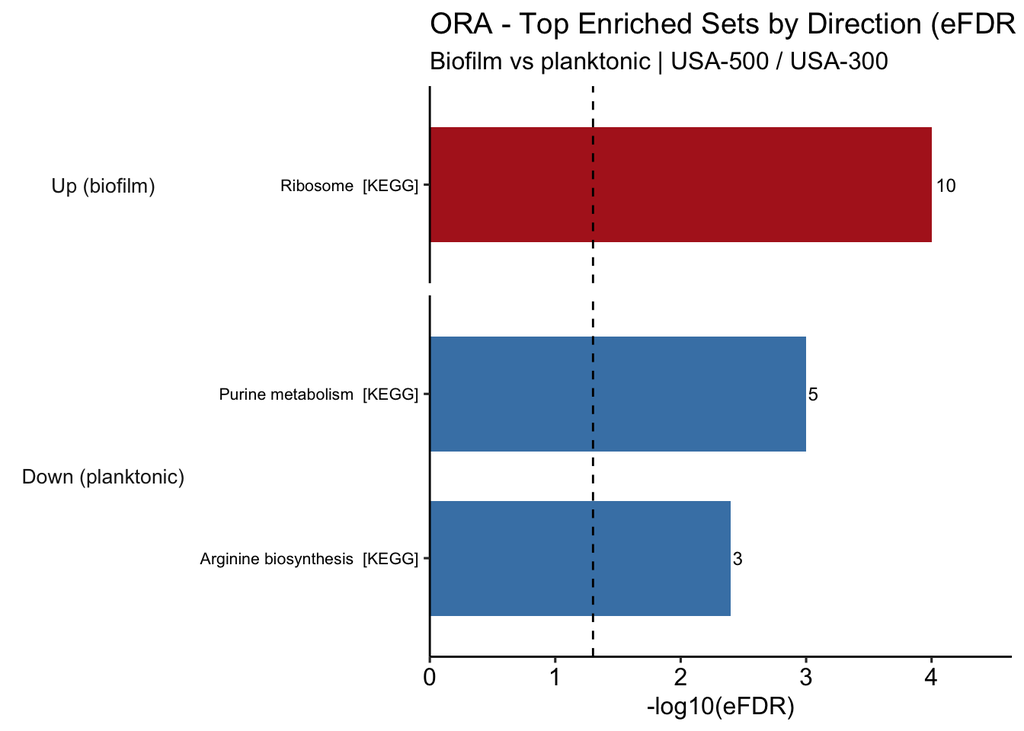

```r
prep_ora <- function(sig, label, n = 8) {
  if (nrow(sig) == 0) return(NULL)
  sig %>%
    slice_head(n = n) %>%
    transmute(
      set_label = paste0(ontology_name, "  [", source, "]"),
      hits      = nr_common_with_tested_elements,
      eFDR      = ifelse(eFDR == 0, 1e-4, eFDR),  # floor for plotting log
      neglog10  = -log10(eFDR),
      direction = label
    )
}

ora_plot_df <- bind_rows(
  prep_ora(ora_up_sig,   "Up (biofilm)"),
  prep_ora(ora_down_sig, "Down (planktonic)")
)

if (!is.null(ora_plot_df) && nrow(ora_plot_df) > 0) {
  ora_plot_df <- ora_plot_df %>%
    mutate(
      direction = factor(direction, levels = c("Up (biofilm)", "Down (planktonic)")),
      set_label = reorder(paste(set_label, direction, sep = "___"), neglog10)
    )

  ggplot(ora_plot_df, aes(x = neglog10, y = set_label, fill = direction)) +
    geom_col(width = 0.7, show.legend = FALSE) +
    geom_text(aes(label = hits), hjust = -0.2, size = 3.2) +
    geom_vline(xintercept = -log10(0.05), linetype = "dashed", linewidth = 0.5) +
    facet_grid(direction ~ ., scales = "free_y", space = "free_y", switch = "y") +
    scale_y_discrete(labels = function(x) sub("___.*$", "", x)) +
    scale_fill_manual(values = c("Up (biofilm)"      = "firebrick",
                                 "Down (planktonic)" = "steelblue")) +
    scale_x_continuous(expand = expansion(mult = c(0, 0.16))) +
    theme_pubr() +
    theme(
      strip.background   = element_blank(),
      strip.placement    = "outside",
      strip.text.y.left  = element_text(angle = 0, size = 10),
      panel.grid.major.y = element_blank(),
      axis.text.y        = element_text(size = 8)
    ) +
    labs(
      title    = "ORA - Top Enriched Sets by Direction (eFDR < 0.05)",
      subtitle = paste0("Biofilm vs planktonic | ", cfg$label),
      x        = "-log10(eFDR)",
      y        = NULL
    )
} else {
  cat("No significant sets to plot.\n")
}
```

## Part 2 Gene Set Enrichment Analysis (GSEA)

**GSEA asks: *“Are genes in a set coordinately shifting up or down across the full ranked list?”***

Unlike ORA, GSEA uses **all tested genes**, ranks them by a metric encoding significance and direction, and returns a **Normalised Enrichment Score (NES)**: positive = up in biofilm, negative = up in planktonic.

**How we rank the genes**

`rank = stat`, the Wald statistic from `DESeq2` (log2FoldChange divided by its standard error)

Genes at the top went up in biofilm *and* are statistically convincing; genes at the bottom went up in planktonic and are convincing; the uncertain ones sit in the middle. Ranking on fold change alone would be worse: a gene with 1 count in one group and 3 in the other shows a 3-fold change and would land at an extreme, despite telling us nothing.

This is the same ranking used in the human chapter, so the two analyses are directly comparable.

### Prepare the Ranked Gene List

```r
ranked_df <- res_df %>%
  filter(!is.na(stat)) %>%
  mutate(rank_metric = stat) %>%
  arrange(desc(rank_metric)) %>%
  distinct(gene_id, .keep_all = TRUE)

rank_vector        <- ranked_df$rank_metric
names(rank_vector) <- ranked_df$gene_id

cat("Genes in ranked list :", length(rank_vector), "\n")
```

```
## Genes in ranked list : 2275
```

```r
cat("Infinite values      :", sum(!is.finite(rank_vector)), "\n")
```

```
## Infinite values      : 0
```

```r
cat("Top 5 (biofilm)      :", paste(head(names(rank_vector), 5), collapse = ", "), "\n")
```

```
## Top 5 (biofilm)      : SAUSA300_RS13840, SAUSA300_RS04640, SAUSA300_RS06160, SAUSA300_RS02705, SAUSA300_RS08955
```

```r
cat("Bottom 5 (planktonic):", paste(tail(names(rank_vector), 5), collapse = ", "), "\n")
```

```
## Bottom 5 (planktonic): SAUSA300_RS12695, SAUSA300_RS05830, SAUSA300_RS11990, SAUSA300_RS05430, SAUSA300_RS12155
```

### Convert Gene Sets to fgsea Format

`fgsea` takes a named list of gene vectors. We convert all three collections and keep a lookup of each set’s source for labelling.

```r
# Some set names exist in more than one collection (e.g. "DNA replication" is both
# a KEGG pathway and a GO:BP set), so we key on "name [source]" to keep them apart.
set_labels    <- paste0(all_gmt$ontology_name, " [", all_gmt$source, "]")
pathways_list <- setNames(all_gmt$list_of_values, set_labels)
set_source    <- setNames(all_gmt$source,         set_labels)

cat("Sets in fgsea list:", length(pathways_list), "\n")
```

```
## Sets in fgsea list: 212
```

```r
cat("Duplicate bare names disambiguated:",
    sum(duplicated(all_gmt$ontology_name)), "\n")
```

```
## Duplicate bare names disambiguated: 1
```

### Run GSEA

We use `fgseaMultilevel`, which resolves very small p-values more accurately than simple permutation, with `minSize = 10` and `maxSize = 500`.

```r
set.seed(42)

gsea_results <- fgseaMultilevel(
  pathways = pathways_list,
  stats    = rank_vector,
  minSize  = 10,
  maxSize  = 500
) %>%
  as.data.frame() %>%
  mutate(source = set_source[pathway])

cat("Sets tested              :", nrow(gsea_results), "\n")
```

```
## Sets tested              : 116
```

```r
cat("Significant (padj < 0.05):", sum(gsea_results$padj < 0.05, na.rm = TRUE), "\n")
```

```
## Significant (padj < 0.05): 18
```

```r
cat("Nominal (pval < 0.05)    :", sum(gsea_results$pval < 0.05, na.rm = TRUE), "\n")
```

```
## Nominal (pval < 0.05)    : 27
```

**Now the answer to the question in Part 1.** Compare this count with the ORA count you wrote down. GSEA finds substantially more, from the same genes and the same collections.

Nothing was fixed between the two. What changed is the input. **ORA needs a list**, so it starts by cutting your genes into significant and not-significant, throws away everything on the wrong side of the line, and then asks whether the survivors crowd into a set. A gene just under the cutoff counts for exactly as much as a gene that was never expressed: nothing. **GSEA needs a ranking**, so it keeps every tested gene in order and asks whether a set’s members sit higher in that order than chance allows. Twenty genes in a pathway that each moved a little, none of them passing the cutoff, are invisible to ORA and are precisely what GSEA is built to detect.

So neither count is the right answer and neither method is better. They answer different questions, and the one you should report is the one whose question you actually asked.

### Inspect Significant Sets

```r
gsea_sig <- gsea_results %>%
  filter(padj < 0.05) %>%
  arrange(padj)

cat("Significant GSEA sets:", nrow(gsea_sig), "\n")
```

```
## Significant GSEA sets: 18
```

```r
cat("  Activated in biofilm    (NES > 0):", sum(gsea_sig$NES > 0), "\n")
```

```
##   Activated in biofilm    (NES > 0): 4
```

```r
cat("  Activated in planktonic (NES < 0):", sum(gsea_sig$NES < 0), "\n")
```

```
##   Activated in planktonic (NES < 0): 14
```

```r
if (nrow(gsea_sig) > 0) {
  DT::datatable(
    gsea_sig %>%
      select(source, pathway, NES, pval, padj, size) %>%
      mutate(
        direction = ifelse(NES > 0, "Biofilm", "Planktonic"),
        across(where(is.numeric), \(x) signif(x, 3))
      ) %>%
      arrange(desc(abs(NES))),
    rownames   = FALSE,
    colnames   = c("Source", "Set", "NES", "p-value", "padj", "Size", "Higher in"),
    extensions = c("Buttons", "Scroller"),
    options    = list(dom = "Bfrtip", buttons = c("copy", "csv"),
                      scrollX = TRUE, scrollY = 300, scroller = TRUE),
    caption = "Significant GSEA sets (padj < 0.05)"
  )
} else {
  cat("No sets significant after correction. The nominal top sets below are directional only.\n")
}
```

| Source | Set | NES | p-value | padj | Size | Higher in |
| --- | --- | --- | --- | --- | --- | --- |
| GO:BP | translation [GO:BP] | -2.88 | 1.82e-16 | 2.11e-14 | 60 | Planktonic |
| GO:MF | structural constituent of ribosome [GO:MF] | -2.88 | 5.38e-16 | 3.12e-14 | 56 | Planktonic |
| KEGG | Ribosome [KEGG] | -2.39 | 1.2e-08 | 4.65e-07 | 67 | Planktonic |
| KEGG | Purine metabolism [KEGG] | -2.27 | 2.94e-06 | 8.53e-05 | 43 | Planktonic |
| KEGG | Arginine and proline metabolism [KEGG] | 2.11 | 1.43e-05 | 0.000332 | 10 | Biofilm |
| KEGG | Oxidative phosphorylation [KEGG] | -2.08 | 8.33e-05 | 0.00161 | 21 | Planktonic |
| GO:MF | GTPase activity [GO:MF] | -1.99 | 0.000521 | 0.00627 | 16 | Planktonic |
| GO:MF | protein-N(PI)-phosphohistidine-sugar phosphotransferase activity [GO:MF] | -1.98 | 0.000541 | 0.00627 | 10 | Planktonic |
| GO:BP | transmembrane transport [GO:BP] | -1.96 | 0.000257 | 0.00425 | 51 | Planktonic |
| GO:BP | peptidoglycan biosynthetic process [GO:BP] | -1.93 | 0.00276 | 0.0256 | 13 | Planktonic |

[output cut: 8 more lines]

### The biofilm-activated signal

```r
biofilm_sets <- gsea_sig %>% filter(NES > 0) %>% arrange(desc(NES))

if (nrow(biofilm_sets) > 0) {
  cat("Sets significantly activated in biofilm (padj < 0.05, NES > 0):\n")
  for (i in seq_len(nrow(biofilm_sets))) {
    cat(sprintf("  - %s  NES = %.2f, padj = %.3g, size = %d\n",
                biofilm_sets$pathway[i],
                biofilm_sets$NES[i], biofilm_sets$padj[i], biofilm_sets$size[i]))
  }
  cat("\nInterpret small sets with care: a high NES on a set of only a few genes",
      "is fragile. Check the size column above.\n")
} else {
  cat("No gene set is significantly activated in biofilm.\n")
  cat("The biofilm-induced genes do not cluster into any annotated KEGG pathway or GO term.\n")
}
```

```
## Sets significantly activated in biofilm (padj < 0.05, NES > 0):
##   - Arginine and proline metabolism [KEGG]  NES = 2.11, padj = 0.000332, size = 10
##   - Other carbon fixation pathways [KEGG]  NES = 1.77, padj = 0.0377, size = 25
##   - Citrate cycle (TCA cycle) [KEGG]  NES = 1.75, padj = 0.0377, size = 22
##   - Carbon metabolism [KEGG]  NES = 1.59, padj = 0.0344, size = 80
##
## Interpret small sets with care: a high NES on a set of only a few genes is fragile. Check the size column above.
```

### Summary Table of the Top Sets

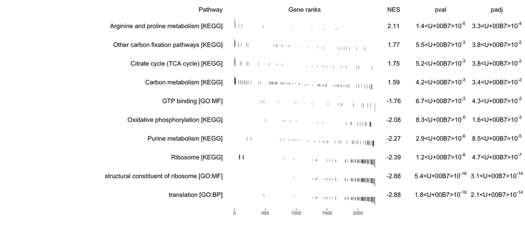

```r
# Keep the source tag when shortening, as in the bar plot below.
tidy_top <- function(x) {
  src  <- str_extract(x, "\\s\\[[^]]+\\]$")
  base <- str_remove(x, "\\s\\[[^]]+\\]$")
  paste0(str_trunc(base, 45), ifelse(is.na(src), "", src))
}

# NB: fgsea loads IRanges, whose slice() masks dplyr's - hence dplyr::slice here.
top_sets <- (if (nrow(gsea_sig) > 0) gsea_sig else gsea_results %>% filter(pval < 0.05)) %>%
  arrange(desc(NES)) %>%
  dplyr::slice(c(1:min(5, dplyr::n()), max(1, dplyr::n() - 4):dplyr::n())) %>%
  dplyr::pull(pathway) %>%
  unique()

if (length(top_sets) > 0) {
  top_pathways <- pathways_list[top_sets]
  names(top_pathways) <- tidy_top(names(top_pathways))

  plotGseaTable(
    pathways  = top_pathways,
    stats     = rank_vector,
    fgseaRes  = gsea_results %>% mutate(pathway = tidy_top(pathway)),
    gseaParam = 0.5
  )
} else {
  cat("No sets to show.\n")
}
```

### NES Bar Plot

If any sets survive correction we plot them; otherwise we fall back to the top sets by nominal p-value and label them clearly as directional, not confirmed.

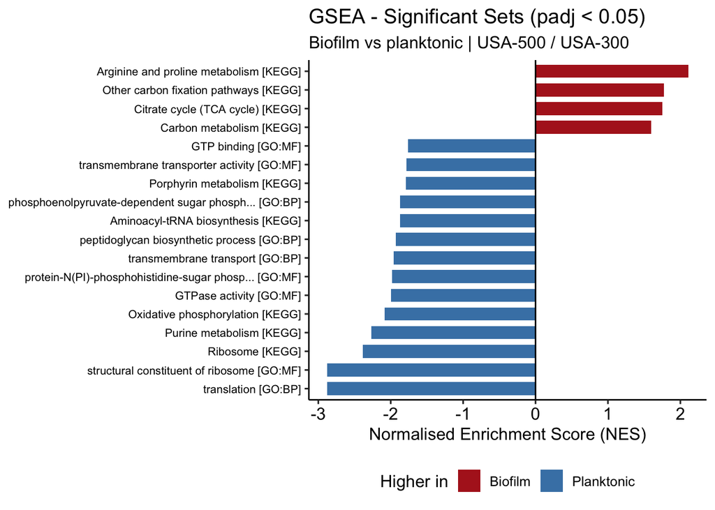

```r
# A handful of GO names run to 70+ characters, which squeezes the bars.
# Trim the name but keep the "[KEGG]" / "[GO:BP]" tag, which says where the set came from.
tidy_set_name <- function(x) {
  src  <- str_extract(x, "\\s\\[[^]]+\\]$")
  base <- str_remove(x, "\\s\\[[^]]+\\]$")
  paste0(str_trunc(base, 45), ifelse(is.na(src), "", src))
}

use_padj <- nrow(gsea_sig) > 0

gsea_bar <- (if (use_padj) gsea_sig
             else gsea_results %>% filter(pval < 0.05)) %>%
  slice_max(abs(NES), n = 20) %>%
  mutate(
    direction = ifelse(NES > 0, "Biofilm", "Planktonic"),
    set_label = fct_reorder(tidy_set_name(pathway), NES)
  )

if (nrow(gsea_bar) > 0) {
  ttl <- if (use_padj) "GSEA - Significant Sets (padj < 0.05)"
         else "GSEA - Top Sets by Nominal p-value (directional only, not padj-significant)"
  ggplot(gsea_bar, aes(x = NES, y = set_label, fill = direction)) +
    geom_col(width = 0.7) +
    geom_vline(xintercept = 0, linewidth = 0.5) +
    scale_fill_manual(values = c("Biofilm" = "firebrick", "Planktonic" = "steelblue")) +
    theme_pubr() +
    theme(legend.position = "bottom",
          axis.text.y = element_text(size = 8)) +
    labs(
      title    = ttl,
      subtitle = paste0("Biofilm vs planktonic | ", cfg$label),
      x        = "Normalised Enrichment Score (NES)",
      y        = NULL,
      fill     = "Higher in"
    )
} else {
  cat("No sets to plot at nominal p < 0.05.\n")
}
```

### Enrichment Plot: Top Sets in Each Direction

The running enrichment score for the single strongest set in each direction. The peak is the enrichment score; the “rug” at the bottom marks where that set’s genes fall in the ranked list.

**How to read it:** the x-axis is every gene, ordered from most biofilm-up (left) to most planktonic-up (right). Each tick in the rug is one gene of the set. If the ticks bunch near one end, the curve climbs to a high peak there - that is coordinated enrichment. Ticks spread evenly across the axis give a flat, wandering curve and no enrichment.

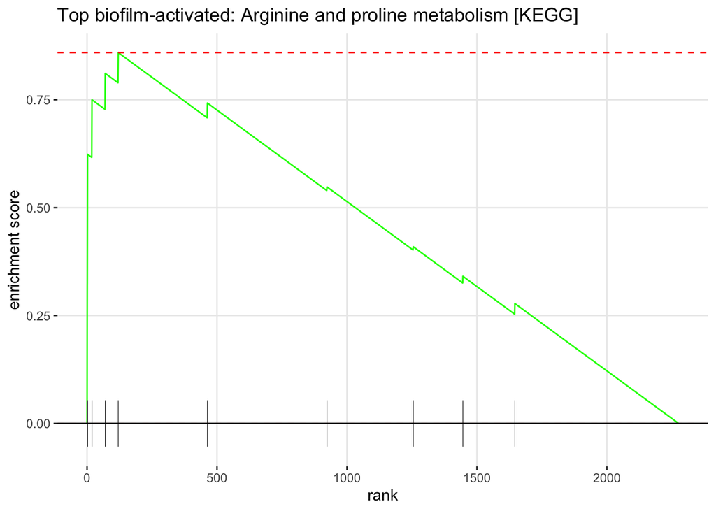

```r
pick_top <- function(res, positive) {
  d <- res %>% filter(if (positive) NES > 0 else NES < 0)
  d <- if (nrow(gsea_sig) > 0) d %>% filter(padj < 0.05) else d %>% filter(pval < 0.05)
  if (nrow(d) == 0) return(NULL)
  d %>% slice_min(pval, n = 1) %>% pull(pathway)
}

top_biofilm    <- pick_top(gsea_results, TRUE)
top_planktonic <- pick_top(gsea_results, FALSE)

if (!is.null(top_biofilm)) {
  print(plotEnrichment(pathways_list[[top_biofilm]], rank_vector) +
          labs(title = paste("Top biofilm-activated:", top_biofilm)))
}
```

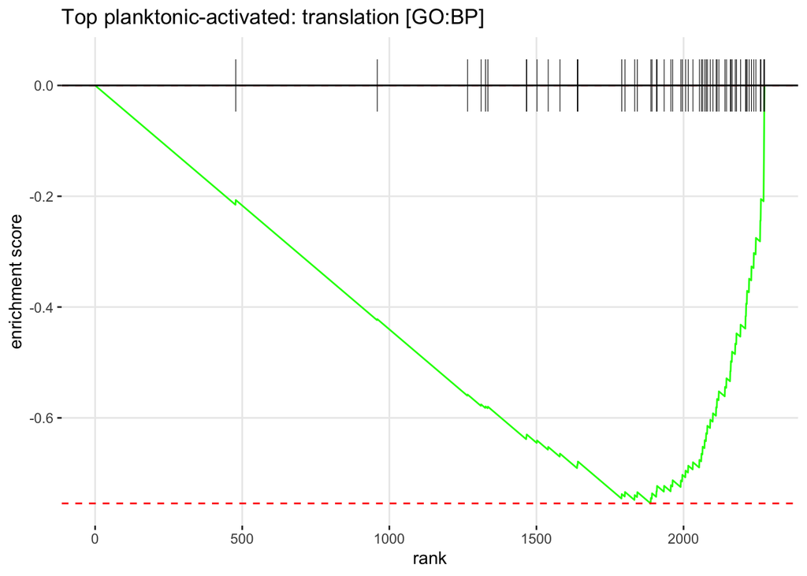

```r
if (!is.null(top_planktonic)) {
  print(plotEnrichment(pathways_list[[top_planktonic]], rank_vector) +
          labs(title = paste("Top planktonic-activated:", top_planktonic)))
}
```

## Part 3 Comparing ORA and GSEA

ORA and GSEA answer different questions and will not always agree. Sets found by both are the highest-confidence results.

```r
# ORA hits get the same "name [source]" labels as the GSEA list, so identically
# named sets from different collections are never conflated.
ora_hits <- unique(c(
  if (nrow(ora_up_sig)   > 0) paste0(ora_up_sig$ontology_name,   " [", ora_up_sig$source,   "]") else character(0),
  if (nrow(ora_down_sig) > 0) paste0(ora_down_sig$ontology_name, " [", ora_down_sig$source, "]") else character(0)
))
gsea_hits <- gsea_sig$pathway

both      <- intersect(ora_hits, gsea_hits)
ora_only  <- setdiff(ora_hits, gsea_hits)
gsea_only <- setdiff(gsea_hits, ora_hits)

cat("Sets significant in BOTH :", length(both),      "\n")
```

```
## Sets significant in BOTH : 2
```

```r
cat("Sets in ORA only         :", length(ora_only),  "\n")
```

```
## Sets in ORA only         : 1
```

```r
cat("Sets in GSEA only        :", length(gsea_only), "\n")
```

```
## Sets in GSEA only        : 16
```

```r
if (length(both) > 0) {
  cat("\nFound by both methods:\n"); cat(paste(" -", both), sep = "\n")
}
```

```
##
## Found by both methods:
##  - Ribosome [KEGG]
##  - Purine metabolism [KEGG]
```

**Interpretation guide:**

- **Both significant** - high confidence; a strong shift driven by many genes.
- **ORA only** - genes crossing the significance threshold cluster in this set, but the overall coordinated shift may be modest.
- **GSEA only** - a coordinated but subtle shift below the threshold; the genes move together without individually being significant.

### Reading the biology

```r
n_biofilm_sets    <- sum(gsea_sig$NES > 0)
n_planktonic_sets <- sum(gsea_sig$NES < 0)

cat("GSEA sets higher in planktonic:", n_planktonic_sets, "\n")
```

```
## GSEA sets higher in planktonic: 14
```

```r
cat("GSEA sets higher in biofilm   :", n_biofilm_sets, "\n")
```

```
## GSEA sets higher in biofilm   : 4
```

```r
cat("ORA sets among biofilm-up genes:", nrow(ora_up_sig), "\n")
```

```
## ORA sets among biofilm-up genes: 1
```

```r
cat("ORA sets among planktonic-up genes:", nrow(ora_down_sig), "\n")
```

```
## ORA sets among planktonic-up genes: 2
```

## Saving Results

```r
tables_dir <- file.path(git_root, cfg$out, "tables")
dir.create(tables_dir, recursive = TRUE, showWarnings = FALSE)

ora_all <- bind_rows(
  if (!is.null(ora_up)   && nrow(ora_up)   > 0) ora_up   %>% mutate(direction = "Up-biofilm"),
  if (!is.null(ora_down) && nrow(ora_down) > 0) ora_down %>% mutate(direction = "Down-planktonic")
)

if (!is.null(ora_all) && nrow(ora_all) > 0) {
  write.table(
    ora_all %>% select(where(~ !is.list(.))),
    file = file.path(tables_dir,
                     sprintf("ORA_lifestyle_%s.tsv", strain)),
    sep = "\t", quote = FALSE, row.names = FALSE
  )
}

write.table(
  gsea_results %>% select(-leadingEdge),
  file = file.path(tables_dir,
                   sprintf("GSEA_lifestyle_%s.tsv", strain)),
  sep = "\t", quote = FALSE, row.names = FALSE
)

cat("Saved to:", file.path(cfg$out, "tables"), "\n")
```

```
## Saved to: results/usa500/tables
```

```r
cat("  ORA  -> ", sprintf("ORA_lifestyle_%s.tsv", strain), "\n")
```

```
##   ORA  ->  ORA_lifestyle_usa500.tsv
```

```r
cat("  GSEA -> ", sprintf("GSEA_lifestyle_%s.tsv", strain), "\n")
```

```
##   GSEA ->  GSEA_lifestyle_usa500.tsv
```

## Summary

| Step | Choice made | Rationale |
| --- | --- | --- |
| Contrast | Lifestyle (additive): biofilm vs planktonic, time-controlled | Cleanest biofilm/planktonic signal |
| ORA package | `mulea` | Empirical FDR; accounts for gene set interdependence |
| GSEA package | `fgseaMultilevel` | Accurate small p-values; proper NES |
| Gene sets | KEGG + GO:BP + GO:MF (cached) | No MSigDB/g:Profiler for these strains; built from KEGG + genome GO |
| Gene set key | Locus tag | 100% gene coverage; symbols exist for only ~1/3 of genes |
| ID conversion | None | DE table and gene sets share the pipeline’s locus tags |
| Background | All genes tested for this contrast | Correct statistical background, not the whole genome |
| GSEA rank metric | `stat` (Wald statistic) | Encodes direction and significance; same as the human chapter |
| Significance | padj < 0.05, tested against the 3-fold threshold, checked vs upstream | Matches the paper and script 02; cross-check should reach 100% |

Results are saved and ready for biological interpretation. Read KEGG, GO:BP and GO:MF results together: agreement across collections and between ORA and GSEA is the strongest evidence.

## Interpretation questions

1. From your ORA results, pick the enriched set you trust **most** and the one you trust **least**. Defend both using the numbers in your table (how many hits, how big the set, the eFDR) and whether the biology makes sense for a biofilm-planktonic switch.
2. Ribosome and translation gene sets score higher in planktonic cells - at the transcript level. A colleague concludes: “biofilm cells have shut down protein synthesis.” Is that claim justified by your data? What else could explain fewer ribosomal transcripts in biofilm, and what measurement would settle it?